# Settima data challenge

Denise Cantoni

2026-11-04

```r
library(tidyverse)
library(gapminder)
gapminder
```

```
## # A tibble: 1,704 × 6
##    country     continent  year lifeExp      pop gdpPercap
##    <fct>       <fct>     <int>   <dbl>    <int>     <dbl>
##  1 Afghanistan Asia       1952    28.8  8425333      779.
##  2 Afghanistan Asia       1957    30.3  9240934      821.
##  3 Afghanistan Asia       1962    32.0 10267083      853.
##  4 Afghanistan Asia       1967    34.0 11537966      836.
##  5 Afghanistan Asia       1972    36.1 13079460      740.
##  6 Afghanistan Asia       1977    38.4 14880372      786.
##  7 Afghanistan Asia       1982    39.9 12881816      978.
##  8 Afghanistan Asia       1987    40.8 13867957      852.
##  9 Afghanistan Asia       1992    41.7 16317921      649.
## 10 Afghanistan Asia       1997    41.8 22227415      635.
## # ℹ 1,694 more rows
```

## PRIMA DOMANDA

Derive a formula to compute life expectancy of a continent (a group of countries)

Per calcolare l’aspettativa di vita di un intero continente uso una media ponderata dalla popolazione dei singoli stati:i moltiplica l’aspettativa di vita di ciascun paese per la sua popolazione (ottenendo così il totale degli anni vissuti), si sommano questi valori per tutte le nazioni del continente e si divide infine il tutto per la popolazione totale continentale.

```r
aspettativeContinente <- gapminder |>
  mutate(LifeTot = lifeExp * pop) |>
  group_by(continent, year) |>
  summarise(
    PopTot = sum(pop),
    LifeTotContinent = sum(LifeTot),
    LifeExp = LifeTotContinent / PopTot
  ) |>
  select(-PopTot, -LifeTotContinent)

aspettativeContinente
```

```
## # A tibble: 60 × 3
## # Groups:   continent [5]
##    continent  year LifeExp
##    <fct>     <int>   <dbl>
##  1 Africa     1952    38.8
##  2 Africa     1957    40.9
##  3 Africa     1962    43.1
##  4 Africa     1967    45.2
##  5 Africa     1972    47.2
##  6 Africa     1977    49.2
##  7 Africa     1982    51.0
##  8 Africa     1987    52.8
##  9 Africa     1992    53.4
## 10 Africa     1997    53.3
## # ℹ 50 more rows
```

## SECONDA DOMANDA

plot how life expectancy changed over time for each continent

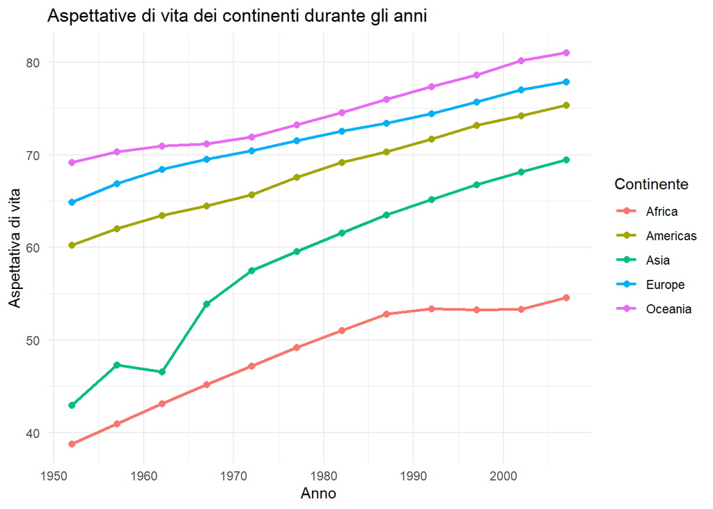

```r
plot <- aspettativeContinente |>
  ggplot(aes(x = year, y = LifeExp, color = continent)) +
  geom_line(linewidth = 1) +
  geom_point(size = 2) +
  labs(
    title = "Aspettative di vita dei continenti durante gli anni",
    x = "Anno",
    y = "Aspettativa di vita",
    color = "Continente"
  ) +
  theme_minimal()

plot
```

Dal grafico si osserva un generale aumento dell’aspettativa di vita in tutti i continenti. Oceania, Europa e Americhe mantengono costantemente i valori più alti con una crescita regolare. Asia e Africa partono dai livelli più bassi, ma registrano l’incremento più marcato: l’Asia ha quasi recuperato i continenti più longevi. Si notano due andamenti interessanti. In asia si è registrato un calo dell’aspettativa di vita poco dopo il 1960, mentre l’Africa mostra un periodo costante tra il 1987 e il 2002, in cui l’aspettativa non è ne cresciuta ne aumentata.

## TERZA DOMANDA

do the same for the whole planet

```r
aspettativaVita <- gapminder |>
  mutate(LifeTot = lifeExp * pop) |>
  group_by(year) |>
  summarise(
    PopTot = sum(pop),
    LifeTotContinent = sum(LifeTot),
    LifeExp = LifeTotContinent / PopTot
  ) |>
  select(-PopTot, -LifeTotContinent)

aspettativaVita
```

```
## # A tibble: 12 × 2
##     year LifeExp
##    <int>   <dbl>
##  1  1952    48.9
##  2  1957    52.1
##  3  1962    52.3
##  4  1967    57.0
##  5  1972    59.5
##  6  1977    61.2
##  7  1982    62.9
##  8  1987    64.4
##  9  1992    65.6
## 10  1997    66.8
## 11  2002    67.8
## 12  2007    68.9
```

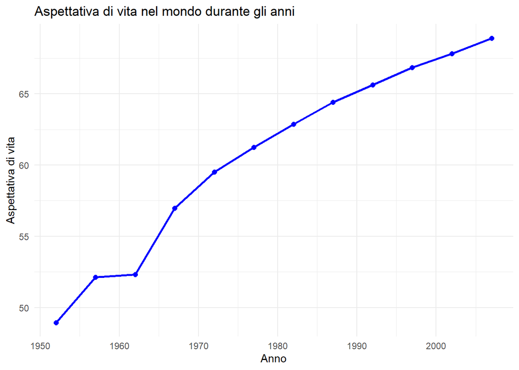

```r
plotMondo <- aspettativaVita |>
  ggplot(aes(x = year, y = LifeExp)) +
  geom_line(color ="blue",linewidth = 1) +
  geom_point(color ="blue", size = 2) +
  labs(
    title = "Aspettativa di vita nel mondo durante gli anni",
    x = "Anno",
    y = "Aspettativa di vita"
  ) +
  theme_minimal()

plotMondo
```

Dal grafico si osserva una crescita costante dell’aspettativa di vita globale, che passa da poco meno di 50 anni nel 1952 a più di 65 dopo gli anni 2000. L’andamento mostra una breve periodo di stasi attorno al 1960, seguita da un forte incremento.